# Risk Factor Analysis

## Outcome Variable

**Outcome Variable:** wast_rec90d

## Predictor Variables

**Intervention Variable:** mwtkg

**Adjustment Set:**

unadjusted

## Stratifying Variables

The analysis was stratified on these variable(s):

- agecat
- studyid
- country

## Data Summary

| agecat | studyid | country | mwtkg | wast_rec90d | n_cell | n |
| --- | --- | --- | --- | --- | --- | --- |
| 0-24 months | ki0047075b-MAL-ED | BANGLADESH | >=58 kg | 0 | 3 | 122 |
| 0-24 months | ki0047075b-MAL-ED | BANGLADESH | >=58 kg | 1 | 9 | 122 |
| 0-24 months | ki0047075b-MAL-ED | BANGLADESH | <52 kg | 0 | 36 | 122 |
| 0-24 months | ki0047075b-MAL-ED | BANGLADESH | <52 kg | 1 | 58 | 122 |
| 0-24 months | ki0047075b-MAL-ED | BANGLADESH | [52-58) kg | 0 | 5 | 122 |
| 0-24 months | ki0047075b-MAL-ED | BANGLADESH | [52-58) kg | 1 | 11 | 122 |
| 0-24 months | ki0047075b-MAL-ED | BRAZIL | >=58 kg | 0 | 4 | 23 |
| 0-24 months | ki0047075b-MAL-ED | BRAZIL | >=58 kg | 1 | 8 | 23 |
| 0-24 months | ki0047075b-MAL-ED | BRAZIL | <52 kg | 0 | 0 | 23 |
| 0-24 months | ki0047075b-MAL-ED | BRAZIL | <52 kg | 1 | 2 | 23 |
| 0-24 months | ki0047075b-MAL-ED | BRAZIL | [52-58) kg | 0 | 2 | 23 |
| 0-24 months | ki0047075b-MAL-ED | BRAZIL | [52-58) kg | 1 | 7 | 23 |
| 0-24 months | ki0047075b-MAL-ED | INDIA | >=58 kg | 0 | 4 | 175 |
| 0-24 months | ki0047075b-MAL-ED | INDIA | >=58 kg | 1 | 8 | 175 |
| 0-24 months | ki0047075b-MAL-ED | INDIA | <52 kg | 0 | 55 | 175 |
| 0-24 months | ki0047075b-MAL-ED | INDIA | <52 kg | 1 | 79 | 175 |
| 0-24 months | ki0047075b-MAL-ED | INDIA | [52-58) kg | 0 | 11 | 175 |
| 0-24 months | ki0047075b-MAL-ED | INDIA | [52-58) kg | 1 | 18 | 175 |
| 0-24 months | ki0047075b-MAL-ED | NEPAL | >=58 kg | 0 | 2 | 93 |
| 0-24 months | ki0047075b-MAL-ED | NEPAL | >=58 kg | 1 | 15 | 93 |
| 0-24 months | ki0047075b-MAL-ED | NEPAL | <52 kg | 0 | 13 | 93 |
| 0-24 months | ki0047075b-MAL-ED | NEPAL | <52 kg | 1 | 36 | 93 |
| 0-24 months | ki0047075b-MAL-ED | NEPAL | [52-58) kg | 0 | 5 | 93 |
| 0-24 months | ki0047075b-MAL-ED | NEPAL | [52-58) kg | 1 | 22 | 93 |
| 0-24 months | ki0047075b-MAL-ED | PERU | >=58 kg | 0 | 1 | 34 |
| 0-24 months | ki0047075b-MAL-ED | PERU | >=58 kg | 1 | 8 | 34 |
| 0-24 months | ki0047075b-MAL-ED | PERU | <52 kg | 0 | 5 | 34 |
| 0-24 months | ki0047075b-MAL-ED | PERU | <52 kg | 1 | 14 | 34 |
| 0-24 months | ki0047075b-MAL-ED | PERU | [52-58) kg | 0 | 0 | 34 |
| 0-24 months | ki0047075b-MAL-ED | PERU | [52-58) kg | 1 | 6 | 34 |

[output cut: 252 more lines]

The following strata were considered:

- agecat: 0-24 months, studyid: ki0047075b-MAL-ED, country: BANGLADESH
- agecat: 0-24 months, studyid: ki0047075b-MAL-ED, country: BRAZIL
- agecat: 0-24 months, studyid: ki0047075b-MAL-ED, country: INDIA
- agecat: 0-24 months, studyid: ki0047075b-MAL-ED, country: NEPAL
- agecat: 0-24 months, studyid: ki0047075b-MAL-ED, country: PERU
- agecat: 0-24 months, studyid: ki0047075b-MAL-ED, country: SOUTH AFRICA
- agecat: 0-24 months, studyid: ki0047075b-MAL-ED, country: TANZANIA, UNITED REPUBLIC OF
- agecat: 0-24 months, studyid: ki1000304b-SAS-CompFeed, country: INDIA
- agecat: 0-24 months, studyid: ki1017093-NIH-Birth, country: BANGLADESH
- agecat: 0-24 months, studyid: ki1017093b-PROVIDE, country: BANGLADESH
- agecat: 0-24 months, studyid: ki1017093c-NIH-Crypto, country: BANGLADESH
- agecat: 0-24 months, studyid: ki1066203-TanzaniaChild2, country: TANZANIA, UNITED REPUBLIC OF
- agecat: 0-24 months, studyid: ki1112895-iLiNS-Zinc, country: BURKINA FASO
- agecat: 0-24 months, studyid: ki1119695-PROBIT, country: BELARUS
- agecat: 0-24 months, studyid: ki1126311-ZVITAMBO, country: ZIMBABWE
- agecat: 0-24 months, studyid: ki1148112-LCNI-5, country: MALAWI
- agecat: 0-6 months, studyid: ki0047075b-MAL-ED, country: BANGLADESH
- agecat: 0-6 months, studyid: ki0047075b-MAL-ED, country: BRAZIL
- agecat: 0-6 months, studyid: ki0047075b-MAL-ED, country: INDIA
- agecat: 0-6 months, studyid: ki0047075b-MAL-ED, country: NEPAL
- agecat: 0-6 months, studyid: ki0047075b-MAL-ED, country: PERU
- agecat: 0-6 months, studyid: ki0047075b-MAL-ED, country: SOUTH AFRICA
- agecat: 0-6 months, studyid: ki0047075b-MAL-ED, country: TANZANIA, UNITED REPUBLIC OF
- agecat: 0-6 months, studyid: ki1000304b-SAS-CompFeed, country: INDIA
- agecat: 0-6 months, studyid: ki1017093-NIH-Birth, country: BANGLADESH
- agecat: 0-6 months, studyid: ki1017093b-PROVIDE, country: BANGLADESH
- agecat: 0-6 months, studyid: ki1017093c-NIH-Crypto, country: BANGLADESH
- agecat: 0-6 months, studyid: ki1066203-TanzaniaChild2, country: TANZANIA, UNITED REPUBLIC OF
- agecat: 0-6 months, studyid: ki1119695-PROBIT, country: BELARUS
- agecat: 0-6 months, studyid: ki1126311-ZVITAMBO, country: ZIMBABWE
- agecat: 0-6 months, studyid: ki1148112-LCNI-5, country: MALAWI
- agecat: 6-24 months, studyid: ki0047075b-MAL-ED, country: BANGLADESH
- agecat: 6-24 months, studyid: ki0047075b-MAL-ED, country: BRAZIL
- agecat: 6-24 months, studyid: ki0047075b-MAL-ED, country: INDIA
- agecat: 6-24 months, studyid: ki0047075b-MAL-ED, country: NEPAL
- agecat: 6-24 months, studyid: ki0047075b-MAL-ED, country: PERU
- agecat: 6-24 months, studyid: ki0047075b-MAL-ED, country: SOUTH AFRICA
- agecat: 6-24 months, studyid: ki0047075b-MAL-ED, country: TANZANIA, UNITED REPUBLIC OF
- agecat: 6-24 months, studyid: ki1000304b-SAS-CompFeed, country: INDIA
- agecat: 6-24 months, studyid: ki1017093-NIH-Birth, country: BANGLADESH
- agecat: 6-24 months, studyid: ki1017093b-PROVIDE, country: BANGLADESH
- agecat: 6-24 months, studyid: ki1017093c-NIH-Crypto, country: BANGLADESH
- agecat: 6-24 months, studyid: ki1066203-TanzaniaChild2, country: TANZANIA, UNITED REPUBLIC OF
- agecat: 6-24 months, studyid: ki1112895-iLiNS-Zinc, country: BURKINA FASO
- agecat: 6-24 months, studyid: ki1119695-PROBIT, country: BELARUS
- agecat: 6-24 months, studyid: ki1126311-ZVITAMBO, country: ZIMBABWE
- agecat: 6-24 months, studyid: ki1148112-LCNI-5, country: MALAWI

### Dropped Strata

Some strata were dropped due to rare outcomes:

- agecat: 0-24 months, studyid: ki0047075b-MAL-ED, country: BANGLADESH
- agecat: 0-24 months, studyid: ki0047075b-MAL-ED, country: BRAZIL
- agecat: 0-24 months, studyid: ki0047075b-MAL-ED, country: INDIA
- agecat: 0-24 months, studyid: ki0047075b-MAL-ED, country: NEPAL
- agecat: 0-24 months, studyid: ki0047075b-MAL-ED, country: PERU
- agecat: 0-24 months, studyid: ki0047075b-MAL-ED, country: SOUTH AFRICA
- agecat: 0-24 months, studyid: ki0047075b-MAL-ED, country: TANZANIA, UNITED REPUBLIC OF
- agecat: 0-24 months, studyid: ki1148112-LCNI-5, country: MALAWI
- agecat: 0-6 months, studyid: ki0047075b-MAL-ED, country: BANGLADESH
- agecat: 0-6 months, studyid: ki0047075b-MAL-ED, country: BRAZIL
- agecat: 0-6 months, studyid: ki0047075b-MAL-ED, country: INDIA
- agecat: 0-6 months, studyid: ki0047075b-MAL-ED, country: NEPAL
- agecat: 0-6 months, studyid: ki0047075b-MAL-ED, country: PERU
- agecat: 0-6 months, studyid: ki0047075b-MAL-ED, country: SOUTH AFRICA
- agecat: 0-6 months, studyid: ki0047075b-MAL-ED, country: TANZANIA, UNITED REPUBLIC OF
- agecat: 0-6 months, studyid: ki1017093b-PROVIDE, country: BANGLADESH
- agecat: 0-6 months, studyid: ki1017093c-NIH-Crypto, country: BANGLADESH
- agecat: 0-6 months, studyid: ki1148112-LCNI-5, country: MALAWI
- agecat: 6-24 months, studyid: ki0047075b-MAL-ED, country: BANGLADESH
- agecat: 6-24 months, studyid: ki0047075b-MAL-ED, country: BRAZIL
- agecat: 6-24 months, studyid: ki0047075b-MAL-ED, country: INDIA
- agecat: 6-24 months, studyid: ki0047075b-MAL-ED, country: NEPAL
- agecat: 6-24 months, studyid: ki0047075b-MAL-ED, country: PERU
- agecat: 6-24 months, studyid: ki0047075b-MAL-ED, country: SOUTH AFRICA
- agecat: 6-24 months, studyid: ki0047075b-MAL-ED, country: TANZANIA, UNITED REPUBLIC OF
- agecat: 6-24 months, studyid: ki1017093b-PROVIDE, country: BANGLADESH
- agecat: 6-24 months, studyid: ki1017093c-NIH-Crypto, country: BANGLADESH
- agecat: 6-24 months, studyid: ki1119695-PROBIT, country: BELARUS
- agecat: 6-24 months, studyid: ki1148112-LCNI-5, country: MALAWI

## Methods Detail

We’re interested in the causal parameters $E[Y_a]$ for all values of $a \in \mathcal{A}$. These parameters represent the mean outcome if, possibly contrary to fact, we intervened to set all units to have $A=a$. Under the randomization and positivity assumptions, these are identified by the statistical parameters $\psi_a=E_W[E_{Y|A,W}(Y|A=a,W)]$. In addition, we’re interested in the mean of $Y$, $E[Y]$ under no intervention (the observed mean). We will estimate these parameters by using SuperLearner to fit the relevant likelihood factors – $E_{Y|A,W}(Y|A=a,W)$ and $p(A=a|W)$, and then updating our likelihood fit using a joint TMLE.

For unadjusted analyses ($W=\{\}$), initial likelihoods were estimated using Lrnr_glm to estimate the simple $E(Y|A)$ and Lrnr_mean to estimate $p(A)$. For adjusted analyses, a small library containing Lrnr_glmnet, Lrnr_xgboost, and Lrnr_mean was used.

Having estimated these parameters, we will then use the delta method to estimate relative risks and attributable risks relative to a prespecified baseline level of $A$.

# Results Detail

## Results Plots

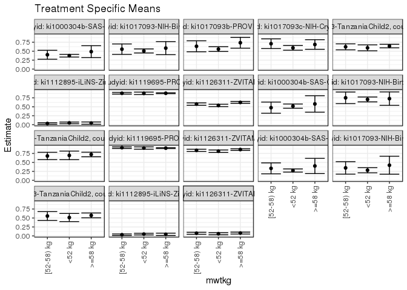

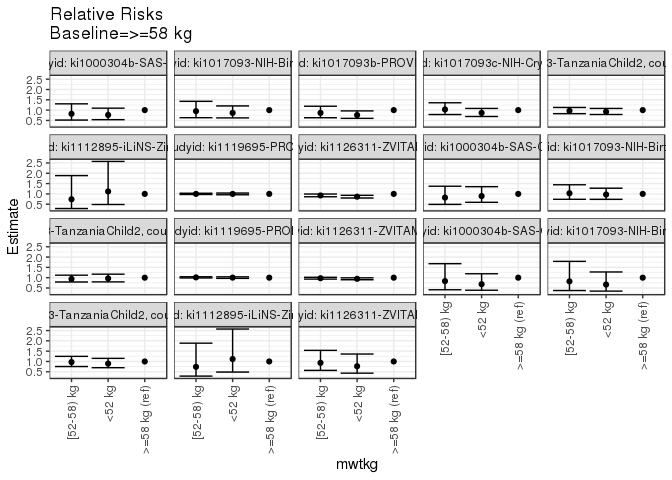

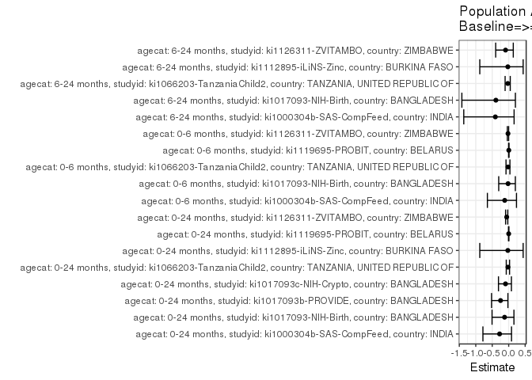

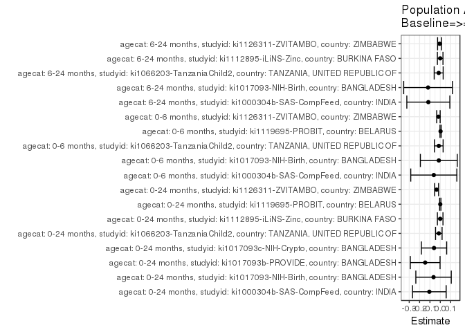

## Results Table

### Parameter: TSM

| agecat | studyid | country | intervention_level | baseline_level | estimate | ci_lower | ci_upper |
| --- | --- | --- | --- | --- | --- | --- | --- |
| 0-24 months | ki1000304b-SAS-CompFeed | INDIA | >=58 kg | NA | 0.4871795 | 0.3202238 | 0.6541352 |
| 0-24 months | ki1000304b-SAS-CompFeed | INDIA | <52 kg | NA | 0.3731778 | 0.3359963 | 0.4103594 |
| 0-24 months | ki1000304b-SAS-CompFeed | INDIA | [52-58) kg | NA | 0.4000000 | 0.2753020 | 0.5246980 |
| 0-24 months | ki1017093-NIH-Birth | BANGLADESH | >=58 kg | NA | 0.5853658 | 0.4034903 | 0.7672414 |
| 0-24 months | ki1017093-NIH-Birth | BANGLADESH | <52 kg | NA | 0.5061350 | 0.4500094 | 0.5622605 |
| 0-24 months | ki1017093-NIH-Birth | BANGLADESH | [52-58) kg | NA | 0.5555556 | 0.4097932 | 0.7013179 |
| 0-24 months | ki1017093b-PROVIDE | BANGLADESH | >=58 kg | NA | 0.7352941 | 0.5846182 | 0.8859701 |
| 0-24 months | ki1017093b-PROVIDE | BANGLADESH | <52 kg | NA | 0.5580357 | 0.4920376 | 0.6240339 |
| 0-24 months | ki1017093b-PROVIDE | BANGLADESH | [52-58) kg | NA | 0.6363636 | 0.4828843 | 0.7898430 |
| 0-24 months | ki1017093c-NIH-Crypto | BANGLADESH | >=58 kg | NA | 0.6862745 | 0.5522317 | 0.8203173 |
| 0-24 months | ki1017093c-NIH-Crypto | BANGLADESH | <52 kg | NA | 0.5924171 | 0.5271268 | 0.6577074 |
| 0-24 months | ki1017093c-NIH-Crypto | BANGLADESH | [52-58) kg | NA | 0.7083333 | 0.5733168 | 0.8433499 |
| 0-24 months | ki1066203-TanzaniaChild2 | TANZANIA, UNITED REPUBLIC OF | >=58 kg | NA | 0.6426859 | 0.5935011 | 0.6918706 |
| 0-24 months | ki1066203-TanzaniaChild2 | TANZANIA, UNITED REPUBLIC OF | <52 kg | NA | 0.5925926 | 0.5100432 | 0.6751420 |
| 0-24 months | ki1066203-TanzaniaChild2 | TANZANIA, UNITED REPUBLIC OF | [52-58) kg | NA | 0.6209150 | 0.5369579 | 0.7048722 |
| 0-24 months | ki1112895-iLiNS-Zinc | BURKINA FASO | >=58 kg | NA | 0.0446927 | 0.0135156 | 0.0758699 |
| 0-24 months | ki1112895-iLiNS-Zinc | BURKINA FASO | <52 kg | NA | 0.0500000 | 0.0272248 | 0.0727752 |
| 0-24 months | ki1112895-iLiNS-Zinc | BURKINA FASO | [52-58) kg | NA | 0.0330579 | 0.0123898 | 0.0537259 |
| 0-24 months | ki1119695-PROBIT | BELARUS | >=58 kg | NA | 0.8774880 | 0.8656644 | 0.8893116 |
| 0-24 months | ki1119695-PROBIT | BELARUS | <52 kg | NA | 0.8757225 | 0.8414450 | 0.9100001 |
| 0-24 months | ki1119695-PROBIT | BELARUS | [52-58) kg | NA | 0.8771186 | 0.8533731 | 0.9008642 |
| 0-24 months | ki1126311-ZVITAMBO | ZIMBABWE | >=58 kg | NA | 0.6219956 | 0.5957154 | 0.6482758 |
| 0-24 months | ki1126311-ZVITAMBO | ZIMBABWE | <52 kg | NA | 0.5376079 | 0.5037765 | 0.5714393 |
| 0-24 months | ki1126311-ZVITAMBO | ZIMBABWE | [52-58) kg | NA | 0.5748792 | 0.5416200 | 0.6081384 |
| 0-6 months | ki1000304b-SAS-CompFeed | INDIA | >=58 kg | NA | 0.5789474 | 0.3498480 | 0.8080467 |
| 0-6 months | ki1000304b-SAS-CompFeed | INDIA | <52 kg | NA | 0.5178571 | 0.4588483 | 0.5768660 |
| 0-6 months | ki1000304b-SAS-CompFeed | INDIA | [52-58) kg | NA | 0.4750000 | 0.3193575 | 0.6306425 |
| 0-6 months | ki1017093-NIH-Birth | BANGLADESH | >=58 kg | NA | 0.7272727 | 0.5399105 | 0.9146349 |
| 0-6 months | ki1017093-NIH-Birth | BANGLADESH | <52 kg | NA | 0.7052023 | 0.6373168 | 0.7730878 |
| 0-6 months | ki1017093-NIH-Birth | BANGLADESH | [52-58) kg | NA | 0.7500000 | 0.5885262 | 0.9114738 |
| 0-6 months | ki1066203-TanzaniaChild2 | TANZANIA, UNITED REPUBLIC OF | >=58 kg | NA | 0.7208122 | 0.6570635 | 0.7845609 |
| 0-6 months | ki1066203-TanzaniaChild2 | TANZANIA, UNITED REPUBLIC OF | <52 kg | NA | 0.6949153 | 0.5752008 | 0.8146297 |
| 0-6 months | ki1066203-TanzaniaChild2 | TANZANIA, UNITED REPUBLIC OF | [52-58) kg | NA | 0.6790123 | 0.5766082 | 0.7814165 |
| 0-6 months | ki1119695-PROBIT | BELARUS | >=58 kg | NA | 0.8977999 | 0.8865084 | 0.9090913 |
| 0-6 months | ki1119695-PROBIT | BELARUS | <52 kg | NA | 0.9006024 | 0.8684453 | 0.9327595 |
| 0-6 months | ki1119695-PROBIT | BELARUS | [52-58) kg | NA | 0.9111111 | 0.8895366 | 0.9326856 |
| 0-6 months | ki1126311-ZVITAMBO | ZIMBABWE | >=58 kg | NA | 0.8587866 | 0.8366601 | 0.8809131 |
| 0-6 months | ki1126311-ZVITAMBO | ZIMBABWE | <52 kg | NA | 0.8116505 | 0.7779636 | 0.8453373 |
| 0-6 months | ki1126311-ZVITAMBO | ZIMBABWE | [52-58) kg | NA | 0.8363971 | 0.8057998 | 0.8669943 |
| 6-24 months | ki1000304b-SAS-CompFeed | INDIA | >=58 kg | NA | 0.4000000 | 0.1876007 | 0.6123993 |
| 6-24 months | ki1000304b-SAS-CompFeed | INDIA | <52 kg | NA | 0.2733990 | 0.2292567 | 0.3175413 |
| 6-24 months | ki1000304b-SAS-CompFeed | INDIA | [52-58) kg | NA | 0.3333333 | 0.1806477 | 0.4860189 |
| 6-24 months | ki1017093-NIH-Birth | BANGLADESH | >=58 kg | NA | 0.4210526 | 0.1702652 | 0.6718400 |
| 6-24 months | ki1017093-NIH-Birth | BANGLADESH | <52 kg | NA | 0.2810458 | 0.2089924 | 0.3530991 |
| 6-24 months | ki1017093-NIH-Birth | BANGLADESH | [52-58) kg | NA | 0.3461538 | 0.1723455 | 0.5199622 |
| 6-24 months | ki1066203-TanzaniaChild2 | TANZANIA, UNITED REPUBLIC OF | >=58 kg | NA | 0.5727273 | 0.5052784 | 0.6401762 |
| 6-24 months | ki1066203-TanzaniaChild2 | TANZANIA, UNITED REPUBLIC OF | <52 kg | NA | 0.5131579 | 0.3996590 | 0.6266568 |
| 6-24 months | ki1066203-TanzaniaChild2 | TANZANIA, UNITED REPUBLIC OF | [52-58) kg | NA | 0.5555556 | 0.4322631 | 0.6788480 |
| 6-24 months | ki1112895-iLiNS-Zinc | BURKINA FASO | >=58 kg | NA | 0.0446927 | 0.0135156 | 0.0758699 |
| 6-24 months | ki1112895-iLiNS-Zinc | BURKINA FASO | <52 kg | NA | 0.0500000 | 0.0272248 | 0.0727752 |
| 6-24 months | ki1112895-iLiNS-Zinc | BURKINA FASO | [52-58) kg | NA | 0.0330579 | 0.0123898 | 0.0537259 |
| 6-24 months | ki1126311-ZVITAMBO | ZIMBABWE | >=58 kg | NA | 0.0791367 | 0.0524699 | 0.1058035 |
| 6-24 months | ki1126311-ZVITAMBO | ZIMBABWE | <52 kg | NA | 0.0608108 | 0.0326861 | 0.0889355 |
| 6-24 months | ki1126311-ZVITAMBO | ZIMBABWE | [52-58) kg | NA | 0.0739437 | 0.0467327 | 0.1011546 |

### Parameter: E(Y)

| agecat | studyid | country | intervention_level | baseline_level | estimate | ci_lower | ci_upper |
| --- | --- | --- | --- | --- | --- | --- | --- |
| 0-24 months | ki1000304b-SAS-CompFeed | INDIA | NA | NA | 0.3814815 | 0.3463355 | 0.4166275 |
| 0-24 months | ki1017093-NIH-Birth | BANGLADESH | NA | NA | 0.5201900 | 0.4695846 | 0.5707955 |
| 0-24 months | ki1017093b-PROVIDE | BANGLADESH | NA | NA | 0.5894040 | 0.5323948 | 0.6464131 |
| 0-24 months | ki1017093c-NIH-Crypto | BANGLADESH | NA | NA | 0.6258065 | 0.5718723 | 0.6797406 |
| 0-24 months | ki1066203-TanzaniaChild2 | TANZANIA, UNITED REPUBLIC OF | NA | NA | 0.6283688 | 0.5905321 | 0.6662055 |
| 0-24 months | ki1112895-iLiNS-Zinc | BURKINA FASO | NA | NA | 0.0435339 | 0.0292984 | 0.0577695 |
| 0-24 months | ki1119695-PROBIT | BELARUS | NA | NA | 0.8772681 | 0.8671551 | 0.8873812 |
| 0-24 months | ki1126311-ZVITAMBO | ZIMBABWE | NA | NA | 0.5863214 | 0.5686726 | 0.6039701 |
| 0-6 months | ki1000304b-SAS-CompFeed | INDIA | NA | NA | 0.5162242 | 0.4625356 | 0.5699128 |
| 0-6 months | ki1017093-NIH-Birth | BANGLADESH | NA | NA | 0.7130045 | 0.6535890 | 0.7724200 |
| 0-6 months | ki1066203-TanzaniaChild2 | TANZANIA, UNITED REPUBLIC OF | NA | NA | 0.7062315 | 0.6568751 | 0.7555878 |
| 0-6 months | ki1119695-PROBIT | BELARUS | NA | NA | 0.9003922 | 0.8908257 | 0.9099586 |
| 0-6 months | ki1126311-ZVITAMBO | ZIMBABWE | NA | NA | 0.8406948 | 0.8247812 | 0.8566083 |
| 6-24 months | ki1000304b-SAS-CompFeed | INDIA | NA | NA | 0.2845011 | 0.2426711 | 0.3263311 |
| 6-24 months | ki1017093-NIH-Birth | BANGLADESH | NA | NA | 0.3030303 | 0.2377927 | 0.3682679 |
| 6-24 months | ki1066203-TanzaniaChild2 | TANZANIA, UNITED REPUBLIC OF | NA | NA | 0.5570652 | 0.5044805 | 0.6096499 |
| 6-24 months | ki1112895-iLiNS-Zinc | BURKINA FASO | NA | NA | 0.0435339 | 0.0292984 | 0.0577695 |
| 6-24 months | ki1126311-ZVITAMBO | ZIMBABWE | NA | NA | 0.0722166 | 0.0562671 | 0.0881662 |

### Parameter: RR

| agecat | studyid | country | intervention_level | baseline_level | estimate | ci_lower | ci_upper |
| --- | --- | --- | --- | --- | --- | --- | --- |
| 0-24 months | ki1000304b-SAS-CompFeed | INDIA | >=58 kg | >=58 kg | 1.0000000 | 1.0000000 | 1.0000000 |
| 0-24 months | ki1000304b-SAS-CompFeed | INDIA | <52 kg | >=58 kg | 0.7659966 | 0.5360950 | 1.0944903 |
| 0-24 months | ki1000304b-SAS-CompFeed | INDIA | [52-58) kg | >=58 kg | 0.8210526 | 0.5166069 | 1.3049136 |
| 0-24 months | ki1017093-NIH-Birth | BANGLADESH | >=58 kg | >=58 kg | 1.0000000 | 1.0000000 | 1.0000000 |
| 0-24 months | ki1017093-NIH-Birth | BANGLADESH | <52 kg | >=58 kg | 0.8646472 | 0.6216696 | 1.2025920 |
| 0-24 months | ki1017093-NIH-Birth | BANGLADESH | [52-58) kg | >=58 kg | 0.9490741 | 0.6319417 | 1.4253557 |
| 0-24 months | ki1017093b-PROVIDE | BANGLADESH | >=58 kg | >=58 kg | 1.0000000 | 1.0000000 | 1.0000000 |
| 0-24 months | ki1017093b-PROVIDE | BANGLADESH | <52 kg | >=58 kg | 0.7589286 | 0.5989095 | 0.9617023 |
| 0-24 months | ki1017093b-PROVIDE | BANGLADESH | [52-58) kg | >=58 kg | 0.8654545 | 0.6305508 | 1.1878687 |
| 0-24 months | ki1017093c-NIH-Crypto | BANGLADESH | >=58 kg | >=58 kg | 1.0000000 | 1.0000000 | 1.0000000 |
| 0-24 months | ki1017093c-NIH-Crypto | BANGLADESH | <52 kg | >=58 kg | 0.8632363 | 0.6895906 | 1.0806076 |
| 0-24 months | ki1017093c-NIH-Crypto | BANGLADESH | [52-58) kg | >=58 kg | 1.0321429 | 0.7855764 | 1.3560983 |
| 0-24 months | ki1066203-TanzaniaChild2 | TANZANIA, UNITED REPUBLIC OF | >=58 kg | >=58 kg | 1.0000000 | 1.0000000 | 1.0000000 |
| 0-24 months | ki1066203-TanzaniaChild2 | TANZANIA, UNITED REPUBLIC OF | <52 kg | >=58 kg | 0.9220564 | 0.7865536 | 1.0809028 |
| 0-24 months | ki1066203-TanzaniaChild2 | TANZANIA, UNITED REPUBLIC OF | [52-58) kg | >=58 kg | 0.9661253 | 0.8270983 | 1.1285213 |
| 0-24 months | ki1112895-iLiNS-Zinc | BURKINA FASO | >=58 kg | >=58 kg | 1.0000000 | 1.0000000 | 1.0000000 |
| 0-24 months | ki1112895-iLiNS-Zinc | BURKINA FASO | <52 kg | >=58 kg | 1.1187500 | 0.4863026 | 2.5737094 |
| 0-24 months | ki1112895-iLiNS-Zinc | BURKINA FASO | [52-58) kg | >=58 kg | 0.7396694 | 0.2898718 | 1.8874236 |
| 0-24 months | ki1119695-PROBIT | BELARUS | >=58 kg | >=58 kg | 1.0000000 | 1.0000000 | 1.0000000 |
| 0-24 months | ki1119695-PROBIT | BELARUS | <52 kg | >=58 kg | 0.9979881 | 0.9575183 | 1.0401683 |
| 0-24 months | ki1119695-PROBIT | BELARUS | [52-58) kg | >=58 kg | 0.9995791 | 0.9698036 | 1.0302687 |
| 0-24 months | ki1126311-ZVITAMBO | ZIMBABWE | >=58 kg | >=58 kg | 1.0000000 | 1.0000000 | 1.0000000 |
| 0-24 months | ki1126311-ZVITAMBO | ZIMBABWE | <52 kg | >=58 kg | 0.8643274 | 0.8012214 | 0.9324038 |
| 0-24 months | ki1126311-ZVITAMBO | ZIMBABWE | [52-58) kg | >=58 kg | 0.9242496 | 0.8603342 | 0.9929134 |
| 0-6 months | ki1000304b-SAS-CompFeed | INDIA | >=58 kg | >=58 kg | 1.0000000 | 1.0000000 | 1.0000000 |
| 0-6 months | ki1000304b-SAS-CompFeed | INDIA | <52 kg | >=58 kg | 0.8944805 | 0.5925569 | 1.3502424 |
| 0-6 months | ki1000304b-SAS-CompFeed | INDIA | [52-58) kg | >=58 kg | 0.8204545 | 0.4908259 | 1.3714550 |
| 0-6 months | ki1017093-NIH-Birth | BANGLADESH | >=58 kg | >=58 kg | 1.0000000 | 1.0000000 | 1.0000000 |
| 0-6 months | ki1017093-NIH-Birth | BANGLADESH | <52 kg | >=58 kg | 0.9696532 | 0.7365063 | 1.2766045 |
| 0-6 months | ki1017093-NIH-Birth | BANGLADESH | [52-58) kg | >=58 kg | 1.0312500 | 0.7371449 | 1.4426967 |
| 0-6 months | ki1066203-TanzaniaChild2 | TANZANIA, UNITED REPUBLIC OF | >=58 kg | >=58 kg | 1.0000000 | 1.0000000 | 1.0000000 |
| 0-6 months | ki1066203-TanzaniaChild2 | TANZANIA, UNITED REPUBLIC OF | <52 kg | >=58 kg | 0.9640726 | 0.7943424 | 1.1700696 |
| 0-6 months | ki1066203-TanzaniaChild2 | TANZANIA, UNITED REPUBLIC OF | [52-58) kg | >=58 kg | 0.9420101 | 0.7909114 | 1.1219753 |
| 0-6 months | ki1119695-PROBIT | BELARUS | >=58 kg | >=58 kg | 1.0000000 | 1.0000000 | 1.0000000 |
| 0-6 months | ki1119695-PROBIT | BELARUS | <52 kg | >=58 kg | 1.0031216 | 0.9658567 | 1.0418242 |
| 0-6 months | ki1119695-PROBIT | BELARUS | [52-58) kg | >=58 kg | 1.0148265 | 0.9879785 | 1.0424042 |
| 0-6 months | ki1126311-ZVITAMBO | ZIMBABWE | >=58 kg | >=58 kg | 1.0000000 | 1.0000000 | 1.0000000 |
| 0-6 months | ki1126311-ZVITAMBO | ZIMBABWE | <52 kg | >=58 kg | 0.9451131 | 0.9000529 | 0.9924292 |
| 0-6 months | ki1126311-ZVITAMBO | ZIMBABWE | [52-58) kg | >=58 kg | 0.9739289 | 0.9313113 | 1.0184966 |
| 6-24 months | ki1000304b-SAS-CompFeed | INDIA | >=58 kg | >=58 kg | 1.0000000 | 1.0000000 | 1.0000000 |
| 6-24 months | ki1000304b-SAS-CompFeed | INDIA | <52 kg | >=58 kg | 0.6834975 | 0.3923772 | 1.1906117 |
| 6-24 months | ki1000304b-SAS-CompFeed | INDIA | [52-58) kg | >=58 kg | 0.8333333 | 0.4133009 | 1.6802394 |
| 6-24 months | ki1017093-NIH-Birth | BANGLADESH | >=58 kg | >=58 kg | 1.0000000 | 1.0000000 | 1.0000000 |
| 6-24 months | ki1017093-NIH-Birth | BANGLADESH | <52 kg | >=58 kg | 0.6674837 | 0.3488386 | 1.2771937 |
| 6-24 months | ki1017093-NIH-Birth | BANGLADESH | [52-58) kg | >=58 kg | 0.8221154 | 0.3772729 | 1.7914718 |
| 6-24 months | ki1066203-TanzaniaChild2 | TANZANIA, UNITED REPUBLIC OF | >=58 kg | >=58 kg | 1.0000000 | 1.0000000 | 1.0000000 |
| 6-24 months | ki1066203-TanzaniaChild2 | TANZANIA, UNITED REPUBLIC OF | <52 kg | >=58 kg | 0.8959900 | 0.6973883 | 1.1511493 |
| 6-24 months | ki1066203-TanzaniaChild2 | TANZANIA, UNITED REPUBLIC OF | [52-58) kg | >=58 kg | 0.9700176 | 0.7545103 | 1.2470793 |
| 6-24 months | ki1112895-iLiNS-Zinc | BURKINA FASO | >=58 kg | >=58 kg | 1.0000000 | 1.0000000 | 1.0000000 |
| 6-24 months | ki1112895-iLiNS-Zinc | BURKINA FASO | <52 kg | >=58 kg | 1.1187500 | 0.4863026 | 2.5737094 |
| 6-24 months | ki1112895-iLiNS-Zinc | BURKINA FASO | [52-58) kg | >=58 kg | 0.7396694 | 0.2898718 | 1.8874236 |
| 6-24 months | ki1126311-ZVITAMBO | ZIMBABWE | >=58 kg | >=58 kg | 1.0000000 | 1.0000000 | 1.0000000 |
| 6-24 months | ki1126311-ZVITAMBO | ZIMBABWE | <52 kg | >=58 kg | 0.7684275 | 0.4335954 | 1.3618246 |
| 6-24 months | ki1126311-ZVITAMBO | ZIMBABWE | [52-58) kg | >=58 kg | 0.9343790 | 0.5673171 | 1.5389348 |

### Parameter: PAR

| agecat | studyid | country | intervention_level | baseline_level | estimate | ci_lower | ci_upper |
| --- | --- | --- | --- | --- | --- | --- | --- |
| 0-24 months | ki1000304b-SAS-CompFeed | INDIA | >=58 kg | NA | -0.1056980 | -0.2681979 | 0.0568019 |
| 0-24 months | ki1017093-NIH-Birth | BANGLADESH | >=58 kg | NA | -0.0651758 | -0.2360244 | 0.1056728 |
| 0-24 months | ki1017093b-PROVIDE | BANGLADESH | >=58 kg | NA | -0.1458901 | -0.2895446 | -0.0022357 |
| 0-24 months | ki1017093c-NIH-Crypto | BANGLADESH | >=58 kg | NA | -0.0604681 | -0.1826761 | 0.0617400 |
| 0-24 months | ki1066203-TanzaniaChild2 | TANZANIA, UNITED REPUBLIC OF | >=58 kg | NA | -0.0143171 | -0.0457770 | 0.0171429 |
| 0-24 months | ki1112895-iLiNS-Zinc | BURKINA FASO | >=58 kg | NA | -0.0011588 | -0.0281611 | 0.0258435 |
| 0-24 months | ki1119695-PROBIT | BELARUS | >=58 kg | NA | -0.0002198 | -0.0062819 | 0.0058422 |
| 0-24 months | ki1126311-ZVITAMBO | ZIMBABWE | >=58 kg | NA | -0.0356742 | -0.0549425 | -0.0164060 |
| 0-6 months | ki1000304b-SAS-CompFeed | INDIA | >=58 kg | NA | -0.0627232 | -0.2851766 | 0.1597303 |
| 0-6 months | ki1017093-NIH-Birth | BANGLADESH | >=58 kg | NA | -0.0142682 | -0.1923365 | 0.1638001 |
| 0-6 months | ki1066203-TanzaniaChild2 | TANZANIA, UNITED REPUBLIC OF | >=58 kg | NA | -0.0145807 | -0.0564284 | 0.0272669 |
| 0-6 months | ki1119695-PROBIT | BELARUS | >=58 kg | NA | 0.0025923 | -0.0029886 | 0.0081732 |
| 0-6 months | ki1126311-ZVITAMBO | ZIMBABWE | >=58 kg | NA | -0.0180918 | -0.0347730 | -0.0014106 |
| 6-24 months | ki1000304b-SAS-CompFeed | INDIA | >=58 kg | NA | -0.1154989 | -0.3229953 | 0.0919975 |
| 6-24 months | ki1017093-NIH-Birth | BANGLADESH | >=58 kg | NA | -0.1180223 | -0.3533429 | 0.1172982 |
| 6-24 months | ki1066203-TanzaniaChild2 | TANZANIA, UNITED REPUBLIC OF | >=58 kg | NA | -0.0156621 | -0.0589910 | 0.0276669 |
| 6-24 months | ki1112895-iLiNS-Zinc | BURKINA FASO | >=58 kg | NA | -0.0011588 | -0.0281611 | 0.0258435 |
| 6-24 months | ki1126311-ZVITAMBO | ZIMBABWE | >=58 kg | NA | -0.0069200 | -0.0261714 | 0.0123313 |

### Parameter: PAF

| agecat | studyid | country | intervention_level | baseline_level | estimate | ci_lower | ci_upper |
| --- | --- | --- | --- | --- | --- | --- | --- |
| 0-24 months | ki1000304b-SAS-CompFeed | INDIA | >=58 kg | NA | -0.2770724 | -0.7830303 | 0.0853133 |
| 0-24 months | ki1017093-NIH-Birth | BANGLADESH | >=58 kg | NA | -0.1252923 | -0.5057292 | 0.1590235 |
| 0-24 months | ki1017093b-PROVIDE | BANGLADESH | >=58 kg | NA | -0.2475215 | -0.5202035 | -0.0237510 |
| 0-24 months | ki1017093c-NIH-Crypto | BANGLADESH | >=58 kg | NA | -0.0966242 | -0.3104908 | 0.0823403 |
| 0-24 months | ki1066203-TanzaniaChild2 | TANZANIA, UNITED REPUBLIC OF | >=58 kg | NA | -0.0227845 | -0.0741172 | 0.0260950 |
| 0-24 months | ki1112895-iLiNS-Zinc | BURKINA FASO | >=58 kg | NA | -0.0266185 | -0.8777261 | 0.4387118 |
| 0-24 months | ki1119695-PROBIT | BELARUS | >=58 kg | NA | -0.0002506 | -0.0071847 | 0.0066357 |
| 0-24 months | ki1126311-ZVITAMBO | ZIMBABWE | >=58 kg | NA | -0.0608442 | -0.0942522 | -0.0284562 |
| 0-6 months | ki1000304b-SAS-CompFeed | INDIA | >=58 kg | NA | -0.1215038 | -0.6471022 | 0.2363736 |
| 0-6 months | ki1017093-NIH-Birth | BANGLADESH | >=58 kg | NA | -0.0200114 | -0.3030056 | 0.2015204 |
| 0-6 months | ki1066203-TanzaniaChild2 | TANZANIA, UNITED REPUBLIC OF | >=58 kg | NA | -0.0206458 | -0.0817188 | 0.0369790 |
| 0-6 months | ki1119695-PROBIT | BELARUS | >=58 kg | NA | 0.0028791 | -0.0033400 | 0.0090596 |
| 0-6 months | ki1126311-ZVITAMBO | ZIMBABWE | >=58 kg | NA | -0.0215201 | -0.0415932 | -0.0018338 |
| 6-24 months | ki1000304b-SAS-CompFeed | INDIA | >=58 kg | NA | -0.4059701 | -1.3642228 | 0.1638893 |
| 6-24 months | ki1017093-NIH-Birth | BANGLADESH | >=58 kg | NA | -0.3894737 | -1.4221313 | 0.2029181 |
| 6-24 months | ki1066203-TanzaniaChild2 | TANZANIA, UNITED REPUBLIC OF | >=58 kg | NA | -0.0281153 | -0.1090211 | 0.0468882 |
| 6-24 months | ki1112895-iLiNS-Zinc | BURKINA FASO | >=58 kg | NA | -0.0266185 | -0.8777261 | 0.4387118 |
| 6-24 months | ki1126311-ZVITAMBO | ZIMBABWE | >=58 kg | NA | -0.0958233 | -0.3949017 | 0.1391301 |